# Patent Similarity Computation

This document illustrates a method for computing the similarity among a plurality of patents. The method includes the following steps,

- step 1, extract patent specifications of a specific set of patents, in this case, we extract the specifications of US8848839 and the patents it cited, totally 7 patents.
- step 2, turn the specifications into term document matrix and clean the matrix
- step 3, reduce the dimension of the term documetn matrix as produced in step 2 to avoid curse of dimensionality
- step 4, compute the similarity among the 7 patents based on cosine similarity

#### 1. load required libraries

```r
load <- c("NLP","tm","lsa","XML", "tidyverse")
lapply(load, library, character.only = TRUE)
```

#### 2. construct function **ExtractPatent** to extract patent specifications from **FreePatentOnline**

```r
ExtractPatent <- function(patent_number){
  if (nchar(patent_number) == 11){
    library(XML)
    baseurl <- "http://www.freepatentsonline.com/"
    patentID <- patent_number
    tailurl <- ".html"
    patentID <- strsplit(as.character(patentID),"")[[1]]
    patentID <- append(patentID, "y", after = 0)
    patentID <- append(patentID, "/", after = 5)
    patentID <- paste(patentID, collapse = "")
    patentURL <- paste(baseurl, patentID, tailurl, sep = "")
    myfile <- htmlTreeParse(patentURL, useInternal = TRUE)
    myfile.text = unlist(xpathApply(myfile, '//p', xmlValue))
    myfile.text <- gsub('\\n',' ', myfile.text)
    myfile.text <- paste(myfile.text, collapse = ' ')
    filename <- paste(patentID, ".txt", sep = "")
    file <- file(filename)
    writeLines(myfile.text, file)
    close(file)
  } else {
    library(XML)
    baseurl <- "http://www.freepatentsonline.com/"
    patentID <- patent_number
    tailurl <- ".html"
    patentID <- paste(strsplit(patentID,"")[[1]], collapse = "")
    patentURL <- paste(baseurl, patentID, tailurl, sep = "")
    myfile <- htmlTreeParse(patentURL, useInternal = TRUE)
    myfile.text = unlist(xpathApply(myfile, '//p', xmlValue))
    myfile.text <- gsub('\\n',' ', myfile.text)
    myfile.text <- paste(myfile.text, collapse = ' ')
    filename <- paste(patentID, ".txt", sep = "")
    file <- file(filename)
    writeLines(myfile.text, file)
    close(file)
  }
}
```

#### 3. extract the specifications of the 7 patents with **ExtractPatent**

```r
#p_num <- c("6045043","6098890","6192070","6240538","6498923","6735735")
#map(p_num, ExtractPatent)
```

#### 4. turn the specifications into term document matrix

```r
#function to transform any charactor into a space
toSpace <- content_transformer(function(x, pattern){return (gsub(pattern, " ", x))})

#function to clean corpus
clean_corpus <- function(corpus){
  corpus <- tm_map(corpus, toSpace, "\\[")
  corpus <- tm_map(corpus, toSpace, "\\]")
  corpus <- tm_map(corpus, toSpace, "\\(")
  corpus <- tm_map(corpus, toSpace, "\\)")
  corpus <- tm_map(corpus, toSpace, "\\,")
  corpus <- tm_map(corpus, toSpace, "\\.")
  corpus <- tm_map(corpus, toSpace, "\\;")
  corpus <- tm_map(corpus, toSpace, "\\-")
  corpus <- tm_map(corpus, toSpace, "\"")
  corpus <- tm_map(corpus, toSpace, "\\'")
  corpus <- tm_map(corpus, content_transformer(tolower))
  corpus <- tm_map(corpus, removeNumbers)
  corpus <- tm_map(corpus, removeWords, c(stopwords("en")))
  corpus <- tm_map(corpus, removeWords, c("can","may","embodiments","embodiment","system","vehicle",
                                          "system","include","example","information","data","storage",
                                          "based","device","processing","unit"))
  corpus <- tm_map(corpus, stripWhitespace)
  return(corpus)
}

p_corpus <- VCorpus(DirSource("D:/patent similarity/spec/"), readerControl = list(language="lat"))
p_tdm <- p_corpus %>% clean_corpus() %>%
  TermDocumentMatrix()
p_tdm <- as.matrix(p_tdm)
```

#### 5. compute similarity

```r
#calculate local weighting
LW <- log(1 + p_tdm)

#calculate global weighting
ptdm <- p_tdm/rowSums(p_tdm)
GW <- 1 - entropy(ptdm)/log(ncol(p_tdm))

#calculate entroy weighting
X <- GW*LW

#apply las
mylsa <- lsa(X)

#calculate term vector
termVectors <- mylsa$tk*mylsa$sk

#calculate document vector
docVectors <- mylsa$dk*mylsa$sk

#calculate cosine similarity of document vector
docsim <- cosine(t(docVectors))

#visualization
docsim
```

```
##             6045043.txt 6098890.txt 6192070.txt 6240538.txt 6498923.txt
## 6045043.txt  1.00000000  0.95637849  0.04162316   0.4096503   0.8747441
## 6098890.txt  0.95637849  1.00000000 -0.11094346   0.4844876   0.9312643
## 6192070.txt  0.04162316 -0.11094346  1.00000000   0.5850104   0.1773832
## 6240538.txt  0.40965026  0.48448765  0.58501043   1.0000000   0.7693053
## 6498923.txt  0.87474412  0.93126431  0.17738325   0.7693053   1.0000000
## 6735735.txt -0.17072300  0.07721761  0.03127807   0.6543693   0.3125173
## 8848839.txt  0.72663822  0.79187949  0.37367943   0.9174735   0.9598870
##             6735735.txt 8848839.txt
## 6045043.txt -0.17072300   0.7266382
## 6098890.txt  0.07721761   0.7918795
## 6192070.txt  0.03127807   0.3736794
## 6240538.txt  0.65436926   0.9174735
## 6498923.txt  0.31251725   0.9598870
## 6735735.txt  1.00000000   0.4748215
## 8848839.txt  0.47482154   1.0000000
```

It can be seen from the above matrix that **US8848839** is most similar with **US6240538** and **US6498923**.

Let’s verify the analysis result above by examining which patent did the examiner cite during the prosecution of **US8848839**.

image:

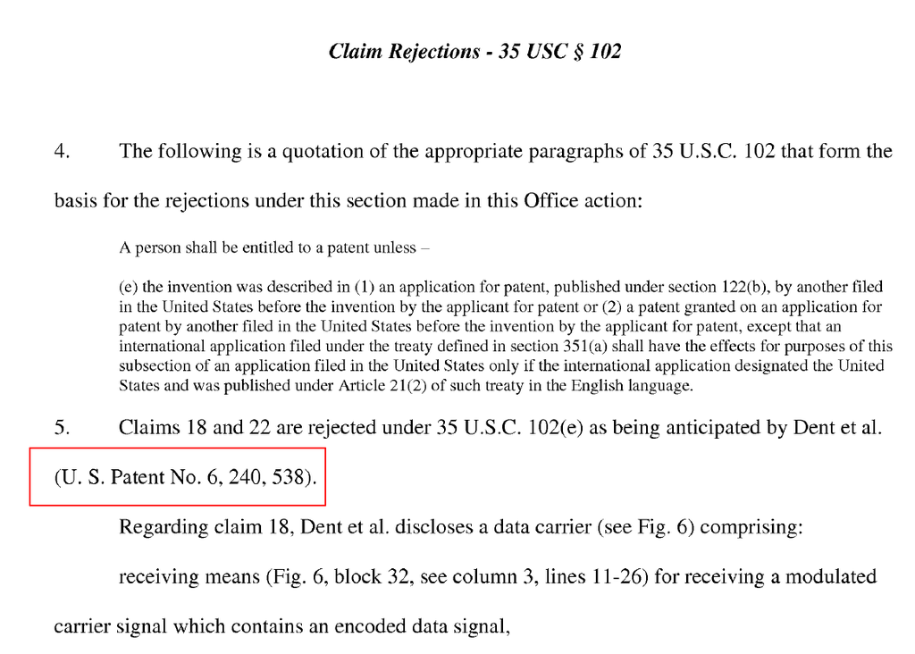

image:

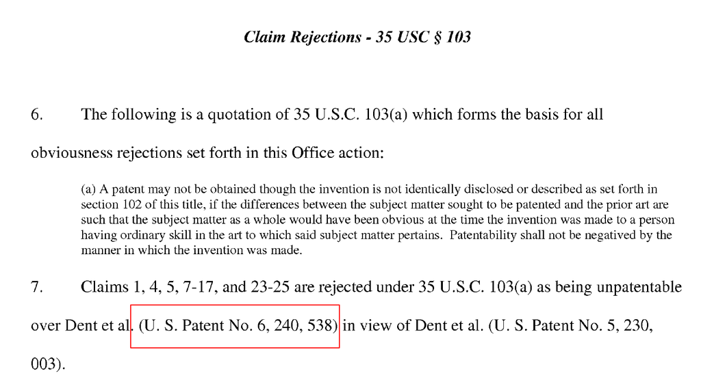

The examiner cited **US6240538**, which is the second most similar patent of **US8848839**, in both 102 rejection and 103 rejection. Thus, this method may be used to assit prior art search. For example, when performing prior art search, we may do a rough search and get a list of potentially similar patents. By using this method, we can sort the list of patents in accordance with their similarity with target patent, and read the sorted list of patents subsequently. By doing so, the efficiency of finding a good reference may be improved.